# Introduction to Data Visualization

January 25, 2016

## Acknowledgments

These slides are adapted from the Coursera JHU Data Science Specialization [course material](https://github.com/DataScienceSpecialization/courses) available through a Creative Commons license and the Swirl [course repository](https://github.com/swirldev/swirl_courses) available through a GNU GPL v3.

Thanks to the original authors for making their material available for reuse and remixing!

These slides are made available under a [Creative Commons BY-NC-SA license](https://creativecommons.org/licenses/by-nc-sa/4.0/), similar to the material from which they were derived.

## Principles of Analytic Graphics

## Principles of Analytic Graphics

[figure not shown]

## Principles of Analytic Graphics

- Principle 1: Show comparisons
- Evidence for a hypothesis is always *relative* to another competing hypothesis.
- Always ask "Compared to What?"

## Show Comparisons

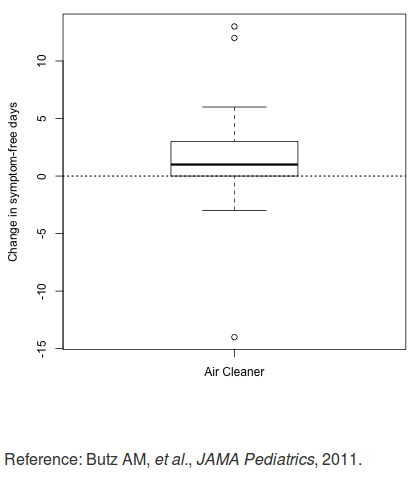

## Show Comparisons

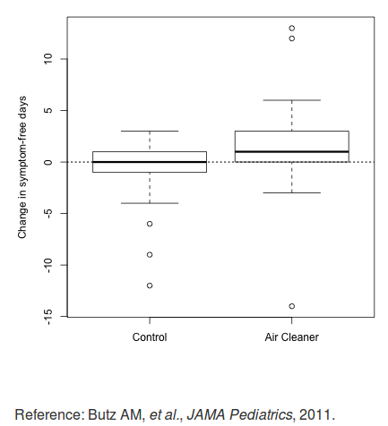

## Principles of Analytic Graphics

- Principle 1: Show comparisons
- Evidence for a hypothesis is always *relative* to another competing hypothesis.
- Always ask "Compared to What?"
- Principle 2: Show causality, mechanism, explanation, systematic structure
- What is your causal framework for thinking about a question?

## Show causality, mechanism

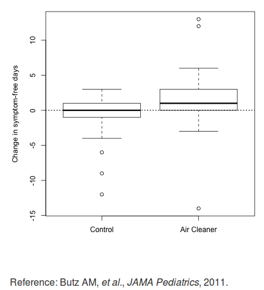

## Show causality, mechanism

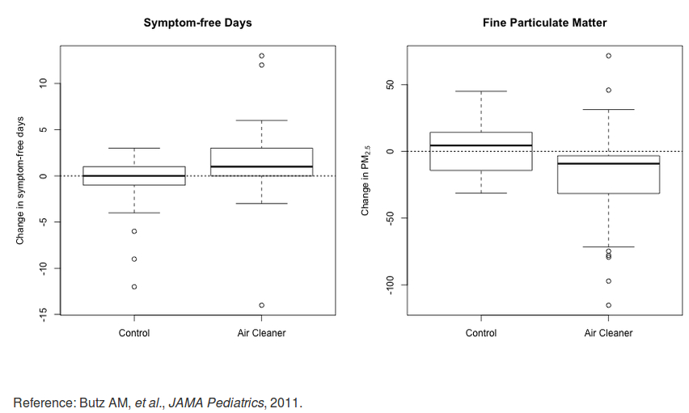

## Principles of Analytic Graphics

- Principle 1: Show comparisons
- Evidence for a hypothesis is always *relative* to another competing hypothesis.
- Always ask "Compared to What?"
- Principle 2: Show causality, mechanism, explanation, systematic structure
- What is your causal framework for thinking about a question?
- Principle 3: Show multivariate data
- Multivariate = more than 2 variables
- The real world is multivariate
- Need to "escape flatland"

## Show Multivariate Data

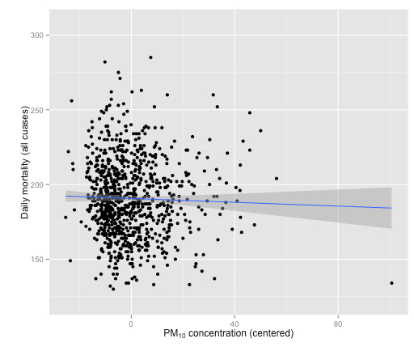

## Show Multivariate Data

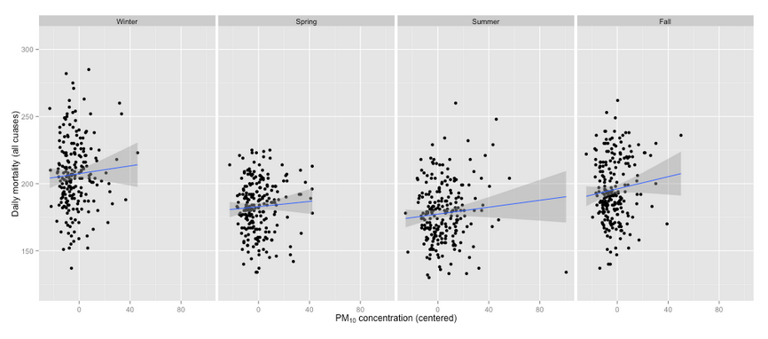

## Principles of Analytic Graphics

- Principle 4: Integration of evidence
- Completely integrate words, numbers, images, diagrams
- Data graphics should make use of many modes of data presentation
- Don't let the tool drive the analysis

## Integrate Different Modes of Evidence

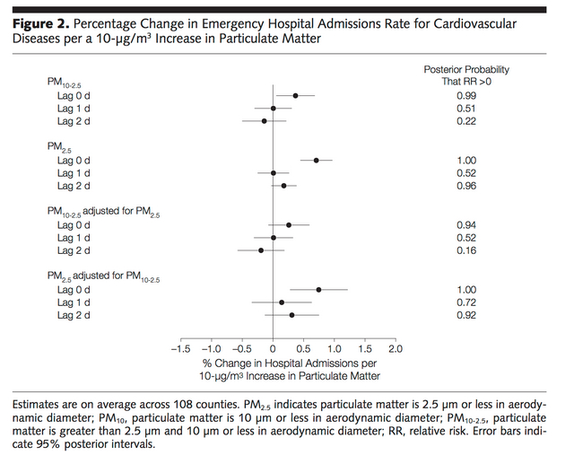

## Principles of Analytic Graphics

- Principle 4: Integration of evidence
- Completely integrate words, numbers, images, diagrams
- Data graphics should make use of many modes of data presentation
- Don't let the tool drive the analysis
- Principle 5: Describe and document the evidence with appropriate labels, scales, sources, etc.
- A data graphic should tell a complete story that is credible

## Principles of Analytic Graphics

- Principle 4: Integration of evidence
- Completely integrate words, numbers, images, diagrams
- Data graphics should make use of many modes of data presentation
- Don't let the tool drive the analysis
- Principle 5: Describe and document the evidence with appropriate labels, scales, sources, etc.
- A data graphic should tell a complete story that is credible
- Principle 6: Content is king
- Analytical presentations ultimately stand or fall depending on the quality, relevance, and integrity of their content

## Summary

- Principle 1: Show comparisons
- Principle 2: Show causality, mechanism, explanation
- Principle 3: Show multivariate data
- Principle 4: Integrate multiple modes of evidence
- Principle 5: Describe and document the evidence
- Principle 6: Content is king

## Exporatory Data Graphics

## Why do we use graphs in data analysis?

- To understand data properties
- To find patterns in data
- To suggest modeling strategies
- To "debug" analyses
- To communicate results

## Exploratory graphs

- To understand data properties
- To find patterns in data
- To suggest modeling strategies
- To "debug" analyses
- To communicate results

## Characteristics of exploratory graphs

- They are made quickly
- A large number are made
- The goal is for personal understanding
- Axes/legends are generally cleaned up (later)
- Color/size are primarily used for information

## Air Pollution in the United States

- The U.S. Environmental Protection Agency (EPA) sets national ambient air quality standards for outdoor air pollution
- [U.S. National Ambient Air Quality Standards](http://www.epa.gov/air/criteria.html)
- For fine particle pollution (PM2.5), the "annual mean, averaged over 3 years" cannot exceed \(12~\mu g/m^3\).
- Data on daily PM2.5 are available from the U.S. EPA web site
- [EPA Air Quality System](http://www.epa.gov/ttn/airs/airsaqs/detaildata/downloadaqsdata.htm)
- **Question**: Are there any counties in the U.S. that exceed that national standard for fine particle pollution?

## Data

Annual average PM2.5 averaged over the period 2008 through 2010

```r
pollution <- read.csv("data/avgpm25.csv",
                      colClasses = c("numeric", "character", "factor", "numeric", "numeric"))
head(pollution)
```

```
##        pm25  fips region longitude latitude
## 1  9.771185 01003   east -87.74826 30.59278
## 2  9.993817 01027   east -85.84286 33.26581
## 3 10.688618 01033   east -87.72596 34.73148
## 4 11.337424 01049   east -85.79892 34.45913
## 5 12.119764 01055   east -86.03212 34.01860
## 6 10.827805 01069   east -85.35039 31.18973
```

Do any counties exceed the standard of \(12~\mu g/m^3\)?

## Simple Summaries of Data

One dimension

- Five-number summary
- Boxplots
- Histograms
- Density plot
- Barplot

## Five Number Summary

```r
summary(pollution$pm25)
```

```
##    Min. 1st Qu.  Median    Mean 3rd Qu.    Max.
##   3.383   8.549  10.050   9.836  11.360  18.440
```

## Boxplot

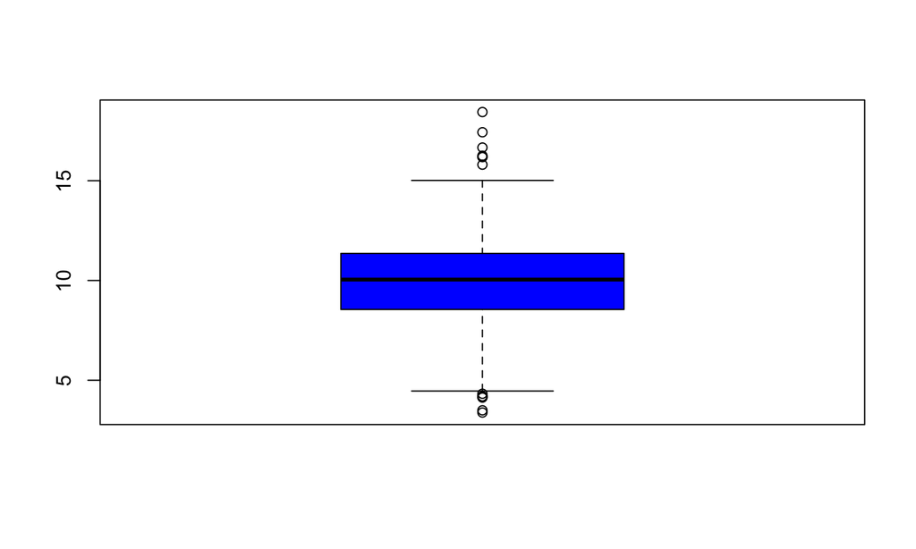

```r
boxplot(pollution$pm25, col = "blue")
```

## Histogram

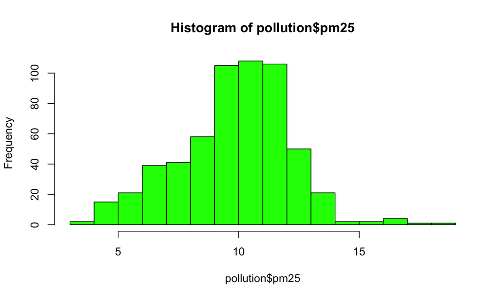

```r
hist(pollution$pm25, col = "green")
```

## Histogram

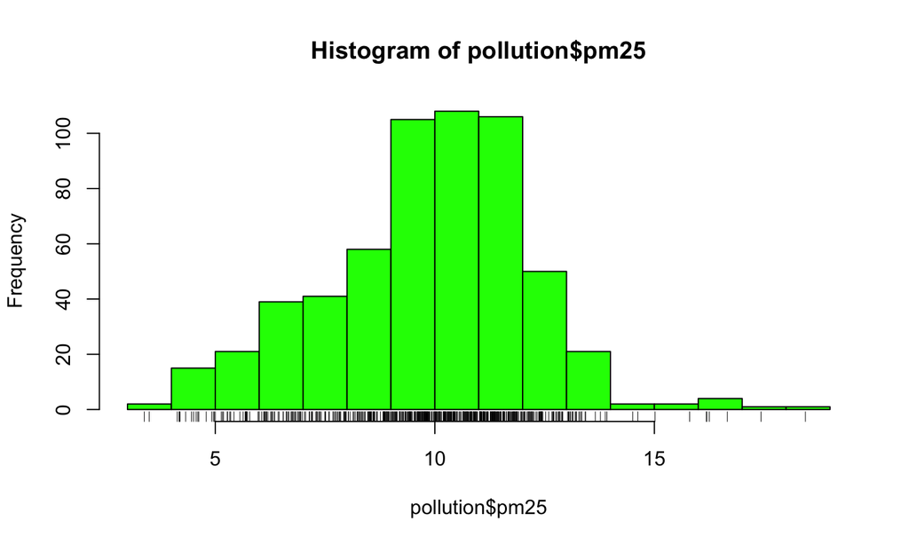

```r
hist(pollution$pm25, col = "green")
rug(pollution$pm25)
```

## Histogram

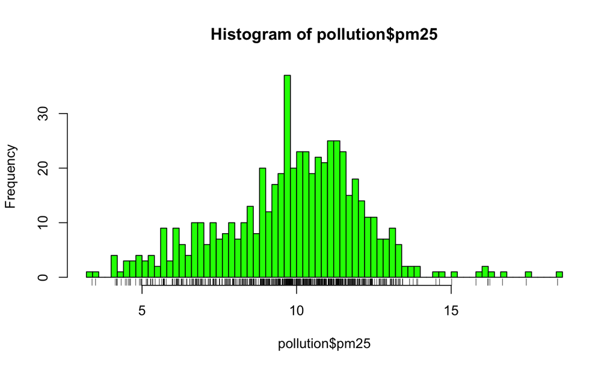

```r
hist(pollution$pm25, col = "green", breaks = 100)
rug(pollution$pm25)
```

## Overlaying Features

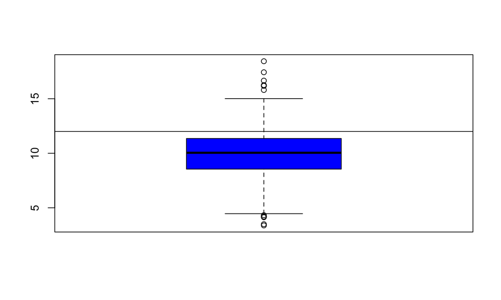

```r
boxplot(pollution$pm25, col = "blue")
abline(h = 12)
```

## Overlaying Features

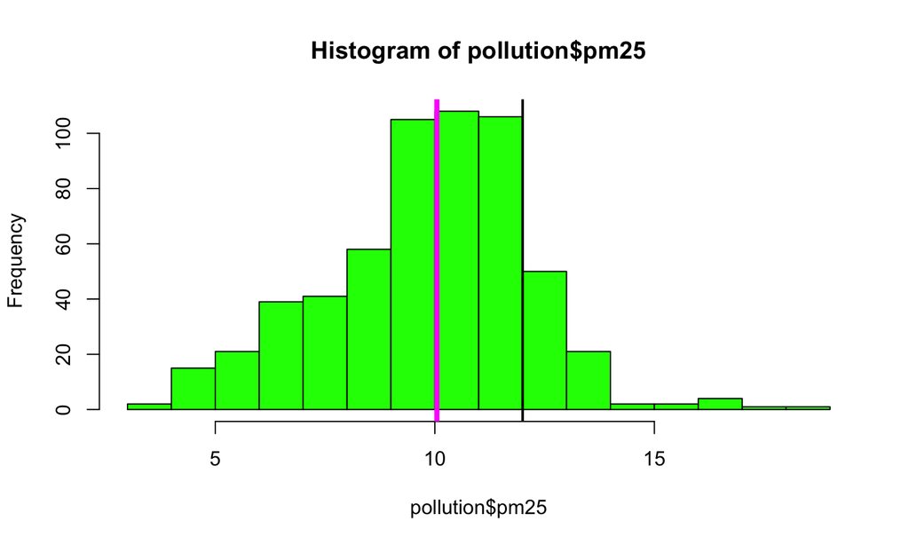

```r
hist(pollution$pm25, col = "green")
abline(v = 12, lwd = 2)
abline(v = median(pollution$pm25), col = "magenta", lwd = 4)
```

## Barplot

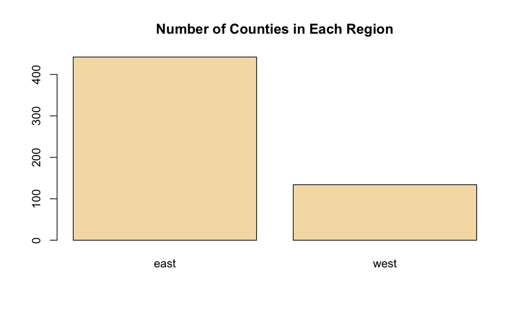

```r
barplot(table(pollution$region), col = "wheat",
        main = "Number of Counties in Each Region")
```

## Simple Summaries of Data

Two dimensions

- Multiple/overlayed 1-D plots (Lattice/ggplot2)
- Scatterplots
- Smooth scatterplots

\(> 2\) dimensions

- Overlayed/multiple 2-D plots; coplots
- Use color, size, shape to add dimensions
- Spinning plots
- Actual 3-D plots (not that useful)

## Multiple Boxplots

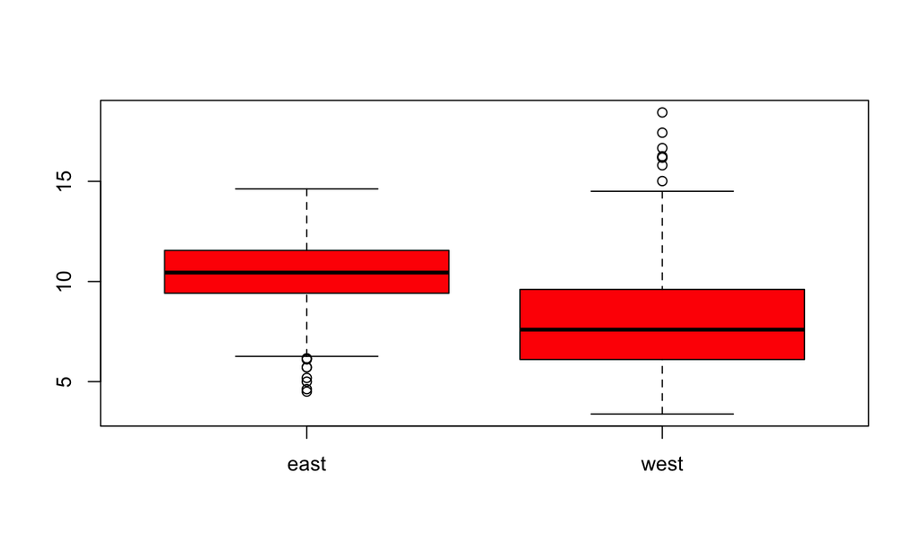

```r
boxplot(pm25 ~ region, data = pollution, col = "red")
```

## Multiple Histograms

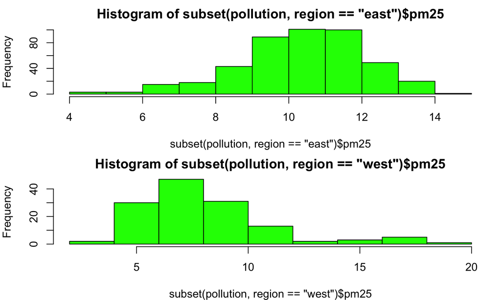

```r
par(mfrow = c(2, 1), mar = c(4, 4, 2, 1))
hist(subset(pollution, region == "east")$pm25, col = "green")
hist(subset(pollution, region == "west")$pm25, col = "green")
```

## Scatterplot

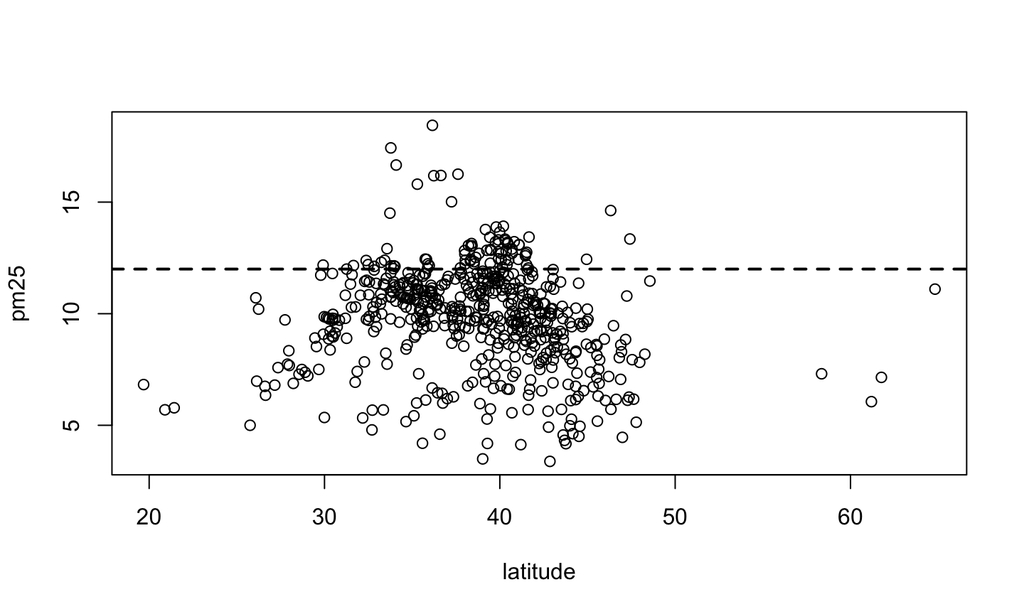

```r
with(pollution, plot(latitude, pm25))
abline(h = 12, lwd = 2, lty = 2)
```

## Scatterplot - Using Color

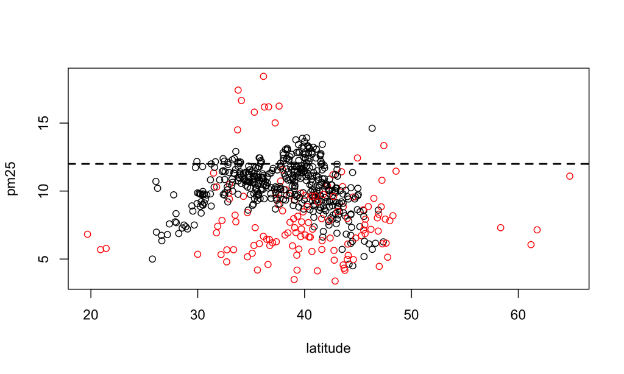

```r
with(pollution, plot(latitude, pm25, col = region))
abline(h = 12, lwd = 2, lty = 2)
```

## Multiple Scatterplots

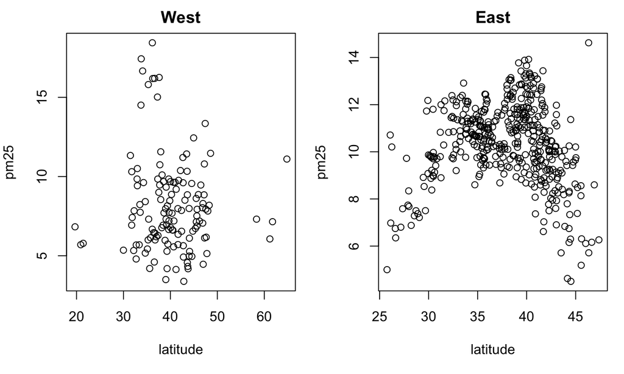

```r
par(mfrow = c(1, 2), mar = c(5, 4, 2, 1))
with(subset(pollution, region == "west"), plot(latitude, pm25, main = "West"))
with(subset(pollution, region == "east"), plot(latitude, pm25, main = "East"))
```

## Summary

- Exploratory plots are "quick and dirty"
- Let you summarize the data (usually graphically) and highlight any broad features
- Explore basic questions and hypotheses (and perhaps rule them out)
- Suggest modeling strategies for the "next step"

## References

- Edward Tufte (2006). *Beautiful Evidence*, Graphics Press LLC. www.edwardtufte.com